# Estadística Descriptiva Multivariada

Análisis de Agrupaciones (Clúster): Métodos de Partición, Jerárquicos y HCPC

Jimmy A Corzo S, PhD

jacorzos@unal.edu.co

Giovany Babativa-Márquez, PhD

jgbabativam@unal.edu.co

# Análisis de Agrupaciones (Clúster)

## ¿Qué es el análisis de agrupaciones (clúster)?

Conjunto de técnicas para agrupar objetos con base en la similitud que tienen en un vector de variables $\mathbf{x}' = (x_1, \ldots, x_p)$, **sin conocer de antemano** a qué grupo pertenece cada uno.

Un buen agrupamiento cumple dos condiciones simultáneas:

1. **Homogeneidad interna**: los objetos dentro de una misma agrupación (clúster) son lo más similares posible.
2. **Heterogeneidad externa**: las agrupaciones (clústeres) se diferencian claramente entre sí.

> A diferencia de la clasificación supervisada, aquí no existe una variable “respuesta” que indique el grupo verdadero: el algoritmo lo construye a partir de la estructura de los datos.

## Aplicaciones típicas

- **Segmentación de mercado**: agrupar clientes según hábitos de consumo para diseñar estrategias diferenciadas.
- **Tipologías sociales**: perfiles de ciudadanos según percepciones, actitudes o comportamientos (encuestas).
- **Caracterización territorial**: agrupar países, departamentos o municipios según indicadores socioeconómicos.
- **Reducción de complejidad**: resumir cientos de observaciones en unos pocos perfiles interpretables.
- **Insumo para otras técnicas**: crear una variable de grupo que luego se use en análisis descriptivo o predictivo.

## Tipos de análisis de agrupaciones (clúster)

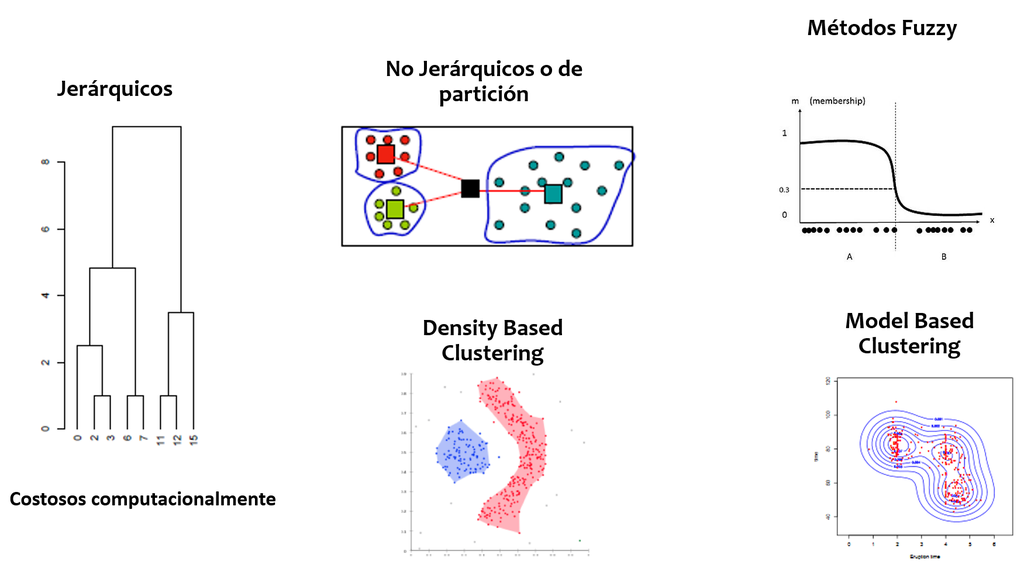

En este curso nos concentramos en los dos enfoques clásicos: **jerárquicos** y **de partición (no jerárquicos)**, y en su combinación mediante **HCPC**.

## Jerárquicos vs. no jerárquicos

**Jerárquicos**

Construyen un árbol (dendrograma) agrupando sucesivamente los elementos o grupos más próximos, sin fijar de antemano el número de agrupaciones (clústeres).

*Costosos computacionalmente para $n$ grande.*

**No jerárquicos (partición)**

Dividen el conjunto de objetos en un número **prefijado** $k$ de grupos, optimizando algún criterio (p. ej. minimizar la varianza intra-agrupación (intra-clúster)).

*Requieren definir $k$ antes de correr el algoritmo.*

## Etapas de un análisis de agrupaciones (clúster)

1. Definir claramente los **objetivos** del análisis.
2. Seleccionar las **variables** relevantes (evitar redundancia).
3. **Estandarizar** las variables para evitar el efecto de la escala.
4. Elegir una **medida de distancia** o disimilaridad.
5. Elegir el **algoritmo** de agrupación.
6. Obtener la **agrupación** y decidir el número de agrupaciones (clústeres).
7. **Validar** e interpretar los resultados.

## Estandarización

Cuando las variables tienen escalas distintas, las de mayor varianza dominan el cálculo de distancias. Se estandariza cada variable como:

$$z_{ij} = \frac{x_{ij} - \bar{x}_j}{s_j}, \qquad j = 1, \ldots, p$$

**Important**

Esto es indispensable quando las variables se miden en unidades diferentes (p. ej. ingresos en pesos y años de educación).

## Medidas de distancia

**Distancia euclídea** (la más usada con variables cuantitativas estandarizadas):

$$d_{ij} = \sqrt{\sum_{k=1}^p (x_{ik} - x_{jk})^2}$$

Otras alternativas según el tipo de variable:

- **Manhattan**: $d_{ij} = \sum_{k=1}^p |x_{ik} - x_{jk}|$ — más robusta a atípicos.
- **Distancia $\chi^2$**: para tablas de frecuencias (la misma del ACS/ACM).
- Existen además otras medidas (p. ej. **Gower**, para mezclas de variables cuantitativas y cualitativas) que no se profundizan en este capítulo.

> Cuando las variables activas provienen de un ACP o un ACM, ya se trabaja sobre coordenadas factoriales, ortogonales y en la misma escala: allí la distancia euclídea es la elección natural.

# Métodos no jerárquicos: K-medias

## El algoritmo de las $K$-medias

Dado un número de grupos $k$, el algoritmo busca la partición que **minimiza la suma de cuadrados intra-agrupación (intra-clúster)**:

$$\min \sum_{c=1}^{k} \sum_{i \in C_c} \| x_i - \bar{x}_c \|^2$$

Dos variantes clásicas:

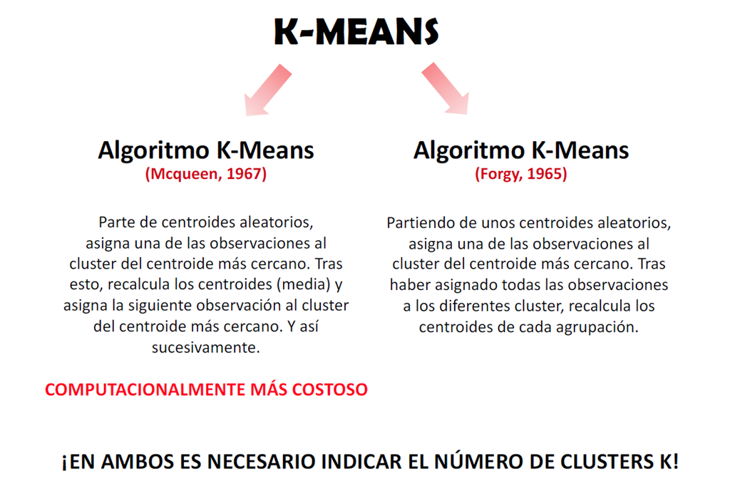

## Algoritmo de las $K$-medias: paso a paso

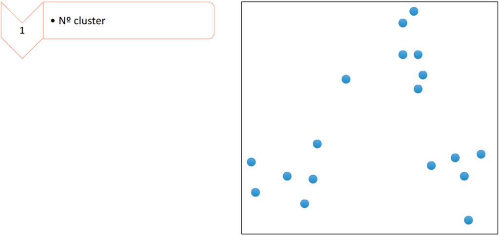

## Algoritmo de las $K$-medias: paso a paso

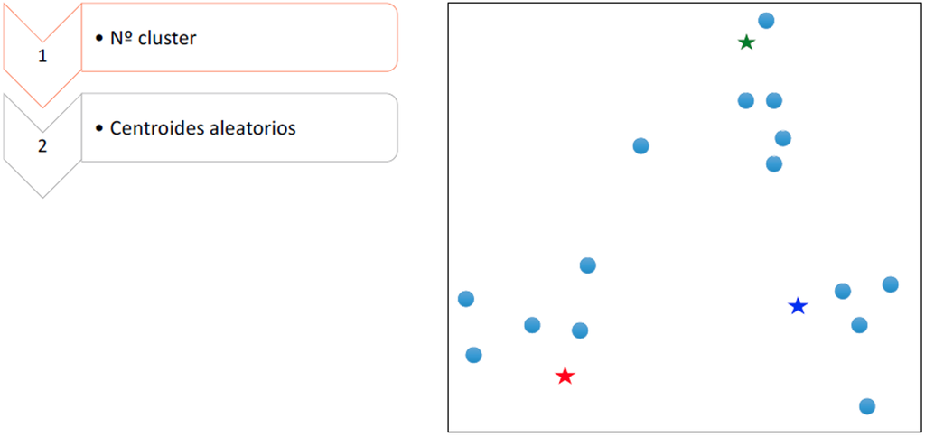

## Algoritmo de las $K$-medias: paso a paso

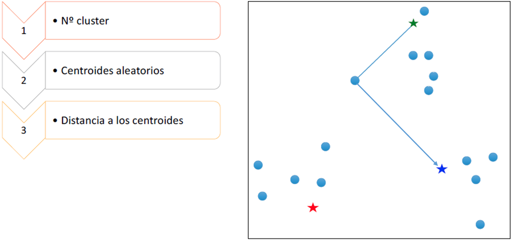

## Algoritmo de las $K$-medias: paso a paso

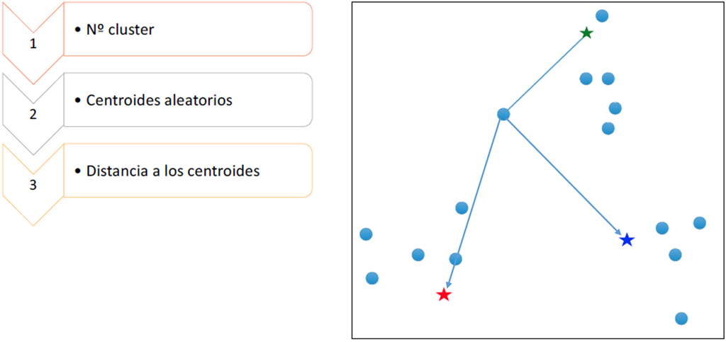

## Algoritmo de las $K$-medias: paso a paso

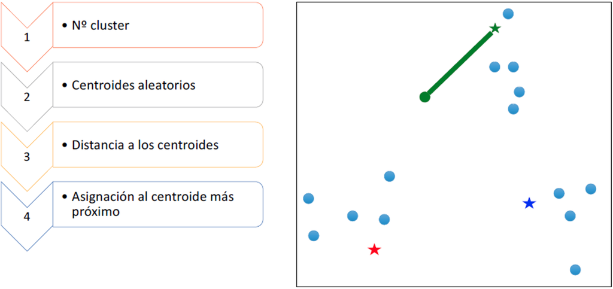

## Algoritmo de las $K$-medias: paso a paso

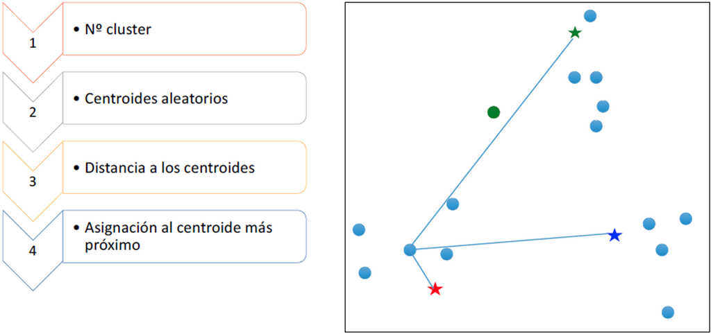

## Algoritmo de las $K$-medias: paso a paso

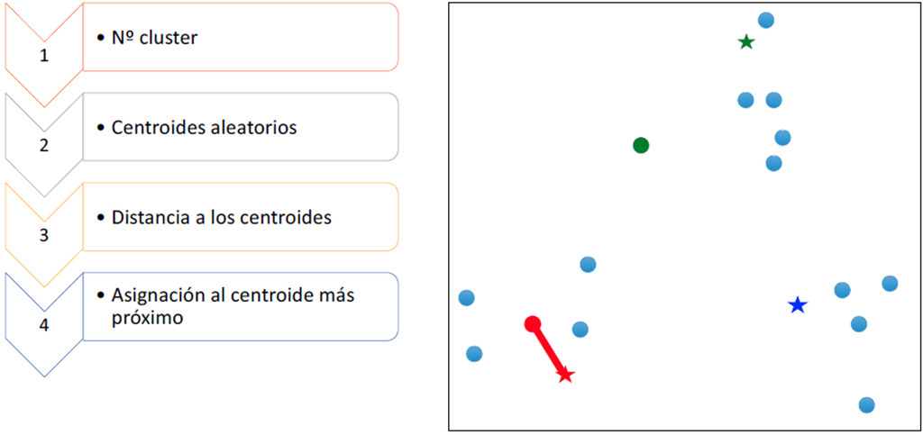

## Algoritmo de las $K$-medias: resultado final

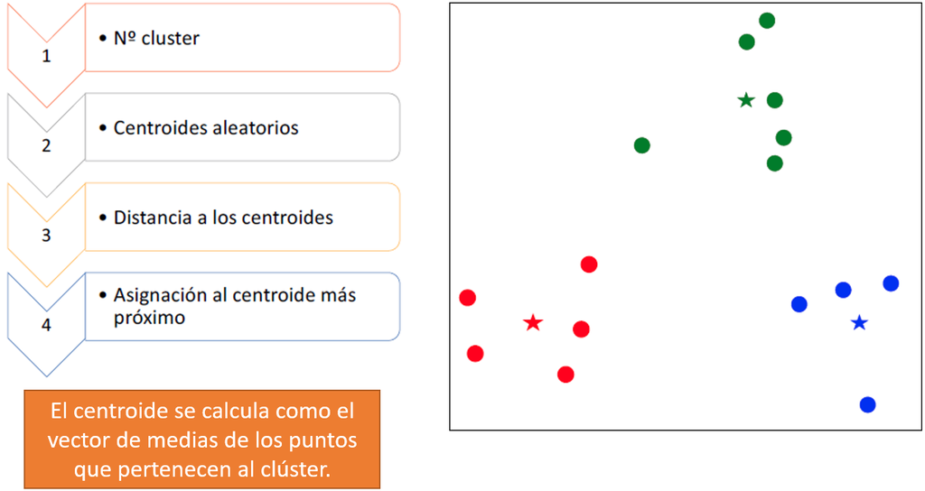

El proceso se repite (reasignar → recalcular centroides) hasta que las asignaciones **no cambian** entre una iteración y la siguiente.

# Ejemplo simulado

## Datos artificiales

Seis objetos descritos por dos variables: gasto mensual y años de educación.

```r
library(pacman)
p_load(here, tidyverse, FactoMineR, factoextra, corrplot, cluster,
       ggrepel, gt, janitor, haven, NbClust)

datos <- data.frame(
  Individuo = c("A", "B", "C", "D", "E", "F"),
  gastos = c(5, 6, 18, 20, 25, 30),
  educa  = c(5, 6, 14, 15, 20, 19)
)
print(datos)
```

```
  Individuo gastos educa
1         A      5     5
2         B      6     6
3         C     18    14
4         D     20    15
5         E     25    20
6         F     30    19
```

## Visualización

```r
ggplot(datos, aes(x = gastos, y = educa, label = Individuo)) +
  geom_point(size = 3, color = "steelblue") +
  geom_text(vjust = -1) +
  labs(x = "Gastos", y = "Años de educación") +
  theme_bw()
```

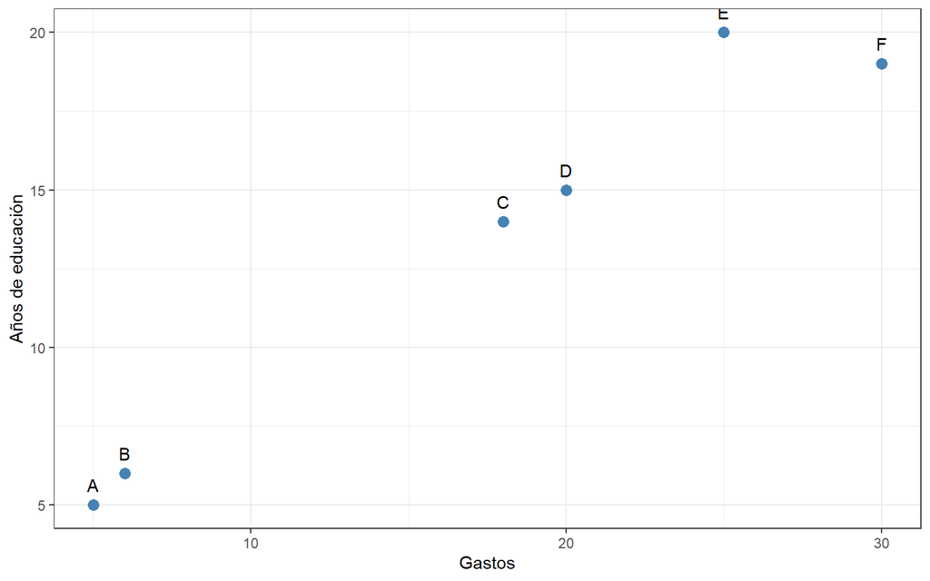

A simple vista se intuyen (al menos) dos grupos: {A, B} y {C, D, E, F}, y posiblemente un tercero {E, F} dentro de este último.

## Estandarización de las variables

$$z_{ij} = \frac{x_{ij} - \bar{x}_j}{s_j}$$

```r
(datos_z <- datos |>
   mutate(gastoz = (gastos - mean(gastos)) / sd(gastos),
          educaz = (educa  - mean(educa))  / sd(educa)))
```

```
  Individuo gastos educa      gastoz     educaz
1         A      5     5 -1.22438718 -1.2822130
2         B      6     6 -1.12511254 -1.1252073
3         C     18    14  0.06618309  0.1308381
4         D     20    15  0.26473236  0.2878437
5         E     25    20  0.76110554  1.0728721
6         F     30    19  1.25747872  0.9158664
```

## Matriz de distancias

```r
mat_z <- datos_z[, c("gastoz", "educaz")]
rownames(mat_z) <- datos_z$Individuo
(distancias <- dist(mat_z))
```

```
          A         B         C         D         E
B 0.1857585
C 1.9137097 1.7311370
D 2.1639212 1.9820147 0.2531256
E 3.0803583 2.8964412 1.1706175 0.9287927
F 3.3152996 3.1373114 1.4266937 1.1747161 0.5206122
```

Los objetos A-B, C-D y E-F son los pares más próximos: son los primeros candidatos a fusionarse en cualquier algoritmo de agrupación.

## Aplicación de $K$-medias ($k=2$)

```r
set.seed(123)
km <- kmeans(datos_z[, c("gastoz", "educaz")], centers = 2)
datos_z$cluster <- as.factor(km$cluster)
km$cluster
```

```
[1] 1 1 2 2 2 2
```

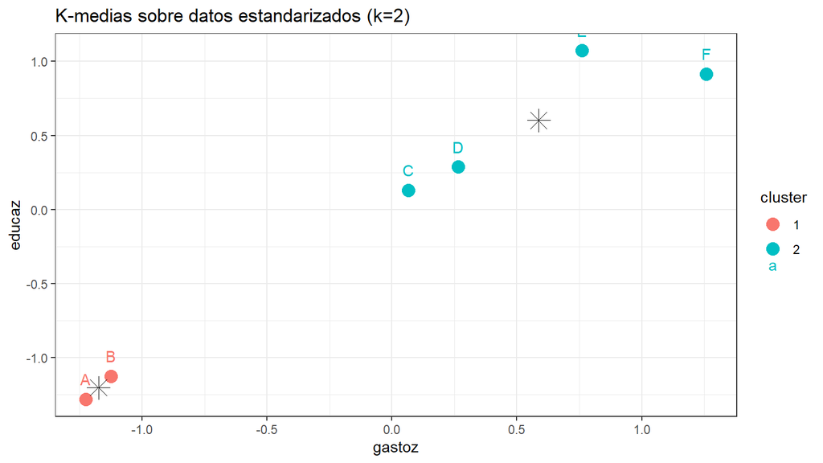

## Métodos para elegir $k$

El número de agrupaciones (clústeres) $k$ debe fijarse **antes** de correr K-medias. Existen varios criterios para ayudar a elegirlo:

- Codo
- Silueta
- Hartigan
- Calinski-Harabasz

**Método del codo (elbow)**

Grafica la suma de cuadrados intra-agrupación (intra-clúster) (WSS) contra $k$:

$$WSS(k) = \sum_{c=1}^{k} \sum_{i \in C_c} \| x_i - \bar{x}_c \|^2$$

$WSS$ siempre **disminuye** al aumentar $k$. Se busca el punto donde la curva deja de descender rápidamente — el “codo” — porque agregar más grupos aporta poca reducción adicional de varianza.

**Ancho de silueta (silhouette)**

Para cada objeto $i$, compara su distancia promedio a los demás miembros de su agrupación (clúster) ($a_i$) con la distancia promedio a la agrupación (clúster) vecina más próxima ($b_i$):

$$s_i = \frac{b_i - a_i}{\max(a_i,\, b_i)}, \qquad s_i \in [-1, 1]$$

Se elige el $k$ que **maximiza** el ancho de silueta promedio $\bar{s}$. Valores cercanos a 1 indican objetos bien agrupados; cercanos a 0 o negativos, mal clasificados.

**Estadístico de Hartigan**

Compara la reducción del WSS al pasar de $k$ a $k+1$ grupos, ajustada por el tamaño de la muestra $n$:

$$H(k) = \left(\frac{WSS(k)}{WSS(k+1)} - 1\right)(n - k - 1)$$

Se aumenta $k$ mientras $H(k)$ sea grande; se elige el primer $k$ en que $H(k)$ cae por debajo de un umbral (usualmente ≈10).

**Índice de Calinski-Harabasz**

Compara la dispersión entre grupos (SSB) con la dispersión dentro de los grupos (SSW), cada una ponderada por sus grados de libertad:

$$CH(k) = \frac{SSB/(k-1)}{SSW/(n-k)}$$

Se elige el $k$ que **maximiza** $CH(k)$.

**Important**

El codo es una regla visual (subjetiva); silueta, Hartigan y Calinski-Harabasz dan un valor numérico comparable entre distintos $k$. Se recomienda usar **varios criterios** junto con el criterio del analista.

## ¿Cómo elegir $k$?

- Método del codo
- Silueta
- Hartigan
- Calinski-Harabasz

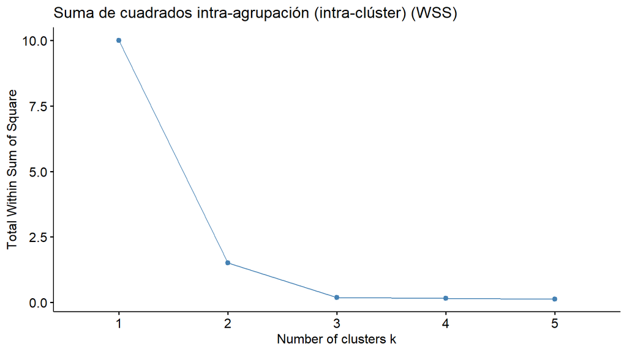

```r
fviz_nbclust(datos_z[, c("gastoz", "educaz")], kmeans,
             method = "wss", k.max = 5) +
  labs(title = "Suma de cuadrados intra-agrupación (intra-clúster) (WSS)")
```

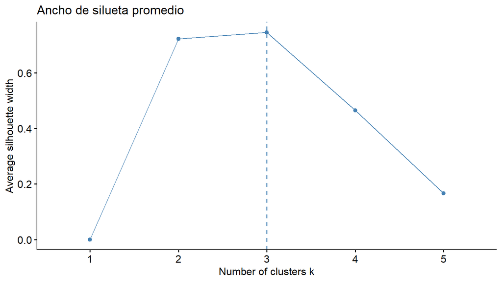

```r
fviz_nbclust(datos_z[, c("gastoz", "educaz")], kmeans,
             method = "silhouette", k.max = 5) +
  labs(title = "Ancho de silueta promedio")
```

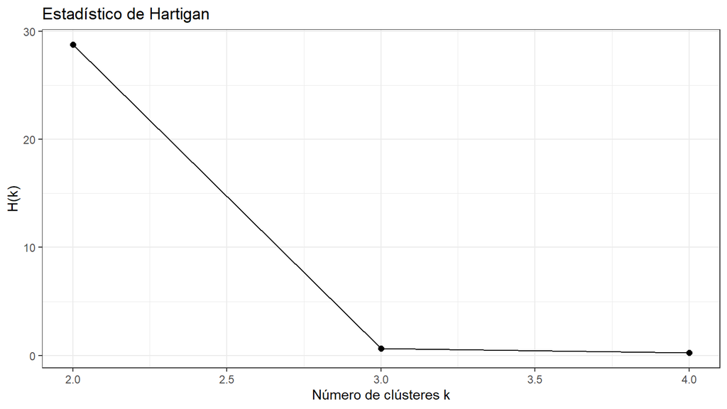

```r
nb_hartigan <- NbClust(datos_z[, c("gastoz", "educaz")], distance = "euclidean",
                        min.nc = 2, max.nc = 4, method = "kmeans", index = "hartigan")

data.frame(k = 2:4, hartigan = nb_hartigan$All.index) |>
  ggplot(aes(x = k, y = hartigan)) +
  geom_line() + geom_point(size = 2) +
  labs(title = "Estadístico de Hartigan", x = "Número de clústeres k", y = "H(k)") +
  theme_bw()
```

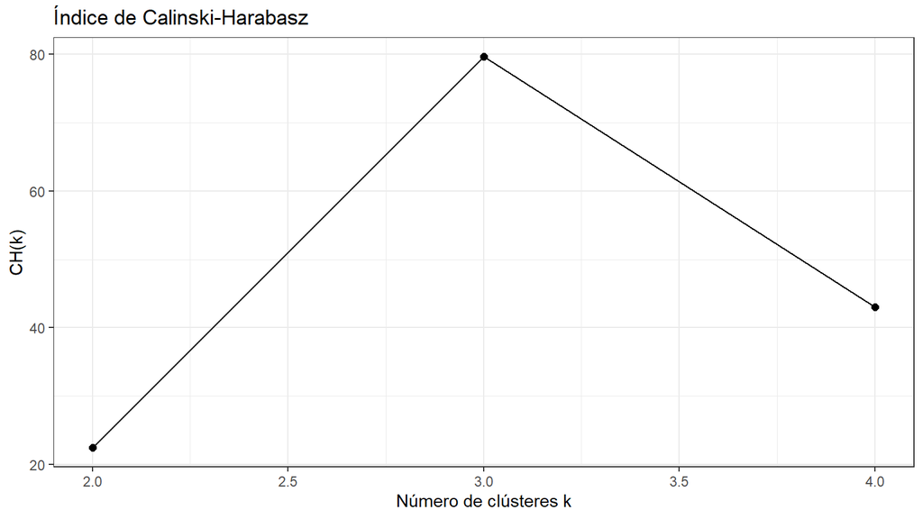

```r
nb_ch <- NbClust(datos_z[, c("gastoz", "educaz")], distance = "euclidean",
                  min.nc = 2, max.nc = 4, method = "kmeans", index = "ch")

data.frame(k = 2:4, ch = nb_ch$All.index) |>
  ggplot(aes(x = k, y = ch)) +
  geom_line() + geom_point(size = 2) +
  labs(title = "Índice de Calinski-Harabasz", x = "Número de clústeres k", y = "CH(k)") +
  theme_bw()
```

# Métodos jerárquicos

## La idea de jerarquía

Los métodos jerárquicos construyen agrupaciones **anidadas**, igual que una clasificación taxonómica: cada nivel agrupa a los elementos del nivel anterior.

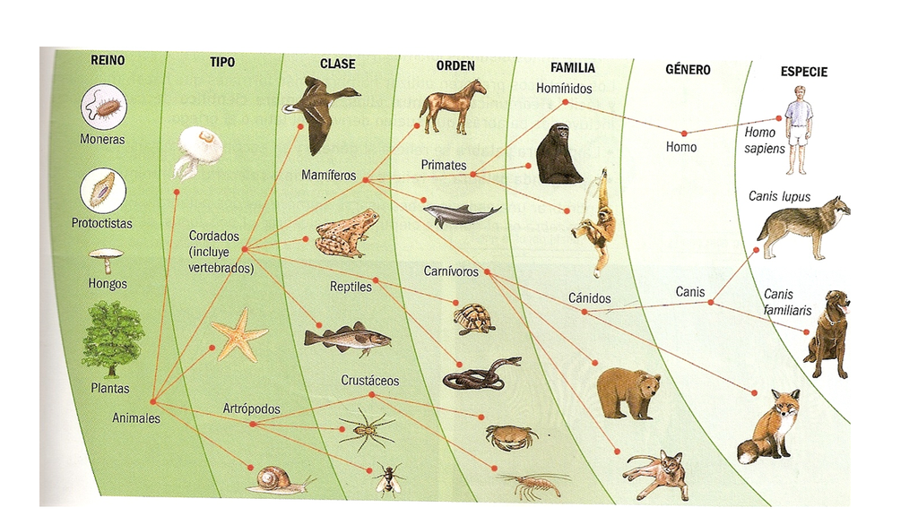

## Algoritmo de aglomeración jerárquica

1. Comenzar con tantos grupos como objetos ($n$ grupos). Las distancias entre grupos son las distancias entre los elementos originales.
2. Fusionar los **dos grupos más próximos** según la matriz de distancias.
3. Sustituir esos dos grupos por uno nuevo que los representa, y **recalcular** las distancias de este nuevo grupo con los demás.
4. Repetir (2) y (3) hasta que todos los elementos queden en un único grupo.

El resultado es un **dendrograma**: un árbol que resume el orden y la “altura” (distancia) a la que se produjo cada fusión.

## Criterios de enlace (linkage)

La forma de “recalcular” la distancia entre grupos define el método:

| Método | Distancia entre grupos $A$ y $B$ | Característica |
| --- | --- | --- |
| **Simple** (single) | $\min_{i\in A, j\in B} d_{ij}$ | Sensible a efecto “cadena” |
| **Completo** (complete) | $\max_{i\in A, j\in B} d_{ij}$ | Grupos compactos, sensible a atípicos |
| **Promedio** (average) | $\frac{1}{\|A\|\|B\|}\sum_{i\in A, j\in B} d_{ij}$ | Compromiso entre los anteriores |
| **Ward** | Mínimo incremento en la inercia intra-agrupación (intra-clúster) al fusionar | El más usado en la práctica |

## Ejemplo simulado: dendrograma

```r
hc_complete <- hclust(distancias, method = "complete")

plot(hc_complete, labels = datos$Individuo,
     main = "Agrupación jerárquica (clúster) (enlace completo)",
     sub = "", xlab = "", ylab = "Distancia")
rect.hclust(hc_complete, k = 2, border = "red")
```

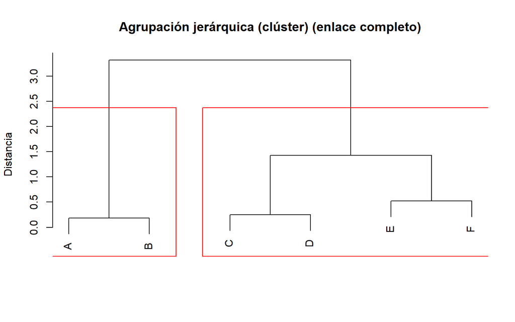

## Comparación de criterios de enlace

- Simple
- Completo
- Promedio
- Ward

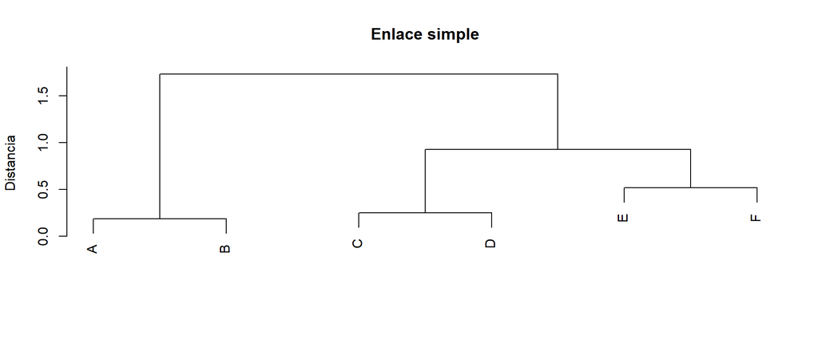

```r
plot(hclust(distancias, method = "single"), labels = datos$Individuo,
     main = "Enlace simple", sub = "", xlab = "", ylab = "Distancia")
```

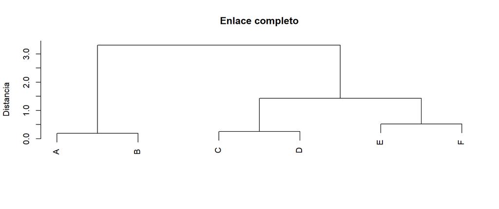

```r
plot(hclust(distancias, method = "complete"), labels = datos$Individuo,
     main = "Enlace completo", sub = "", xlab = "", ylab = "Distancia")
```

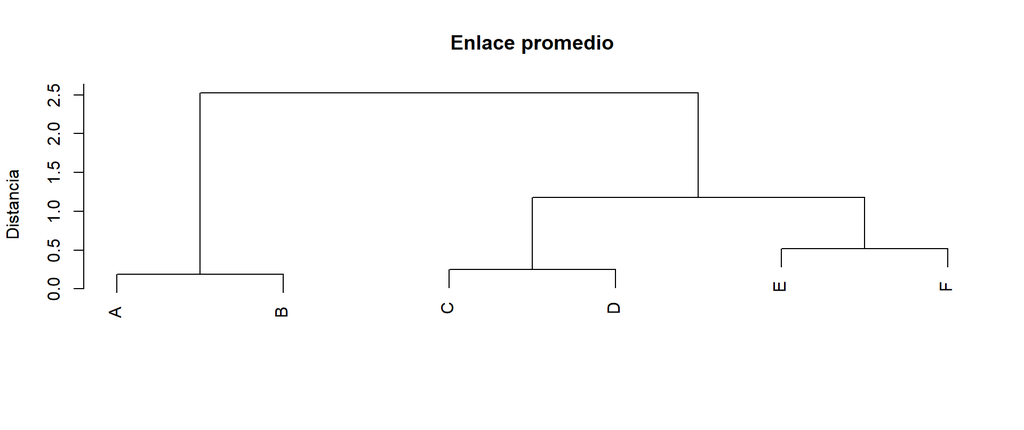

```r
plot(hclust(distancias, method = "average"), labels = datos$Individuo,
     main = "Enlace promedio", sub = "", xlab = "", ylab = "Distancia")
```

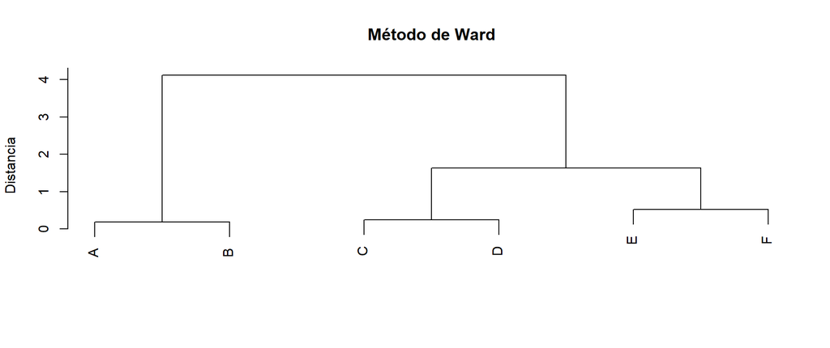

```r
plot(hclust(distancias, method = "ward.D2"), labels = datos$Individuo,
     main = "Método de Ward", sub = "", xlab = "", ylab = "Distancia")
```

En este ejemplo, **los cuatro criterios** coinciden en la partición en dos grupos: {A, B} y {C, D, E, F}, el mismo resultado que arrojó K-medias. En datos reales esto no siempre ocurre: la elección del método sí puede cambiar la agrupación.

## ¿Cuántos grupos retener?

- **Regla visual**: cortar el dendrograma donde la distancia vertical entre fusiones consecutivas sea **grande** (un “salto” evidente).
- **Criterio de inercia**: identificar el número de grupos $k$ a partir del cual la pérdida relativa de inercia inter-agrupación (inter-clúster) al pasar de $k$ a $k-1$ grupos es grande, es decir, al fusionar esos dos grupos quedan siendo menos diferentes entre sí. Se retiene el $k$ inmediatamente anterior a esa pérdida grande.
- Ambos criterios coinciden con la lógica que usa `HCPC()` para sugerir automáticamente un número de grupos.

# HCPC: Clasificación jerárquica sobre componentes principales

## La idea del HCPC

`HCPC()` (*Hierarchical Clustering on Principal Components*) combina lo mejor de los dos mundos vistos hasta ahora, en tres etapas:

1. **Reducción de dimensión**: se parte de las coordenadas factoriales de un ACP, ACM o ACS (en vez de las variables originales).
2. **Clasificación jerárquica** (Ward) sobre esas coordenadas, para construir el dendrograma y sugerir el número de agrupaciones (clústeres).
3. **Consolidación** de la partición con un algoritmo de $K$-medias, partiendo de los centros de gravedad obtenidos en el paso jerárquico, utilizando como valor de $K$ el número de agrupaciones (clústeres) que acaba de generar la clasificación jerárquica en el paso anterior.

## ¿Por qué trabajar sobre componentes?

- Las coordenadas factoriales son **ortogonales**: se elimina la redundancia (correlación) entre variables originales.
- Al retener solo los primeros ejes se **filtra ruido** y se reduce el costo computacional.
- Permite unificar el flujo de trabajo: el **mismo objeto** (`PCA()`, `MCA()` o `CA()`) alimenta tanto el mapa factorial como la clasificación.
- `HCPC()` produce, además del dendrograma, una **caracterización automática** de cada agrupación (clúster): qué variables (o modalidades) lo tipifican.

# Estudio de caso 1: perfiles de calidad de vida departamental

## Los datos

```r
library(pacman)
p_load(tidyverse, FactoMineR, factoextra, gt)
```

Retomamos los 33 departamentos colombianos y sus 15 indicadores de calidad de vida (ECV-DANE 2022) usados en el ACP.

```r
url <- "https://github.com/jgbabativam/EDM/raw/main/Datos/"

ecv <- read.csv(paste0(url, "ecv_departamentos_2022.csv"), header = TRUE) |>
       column_to_rownames("departamento") |>
       rename(inv_hacinamiento = sin_hacinamiento,
              inv_ipm = sin_ipm, leen_adultos = lit_adultos)
```

## Paso 1: ACP (recordatorio)

```r
pca_ecv <- PCA(ecv, graph = FALSE, scale.unit = TRUE, ncp = 5)
```

```r
fviz_eig(pca_ecv, addlabels = TRUE, ncp = 5) +
  labs(title = "Varianza explicada — Calidad de vida ECV 2022",
       x = "Componente", y = "% varianza explicada") + theme_bw()
```

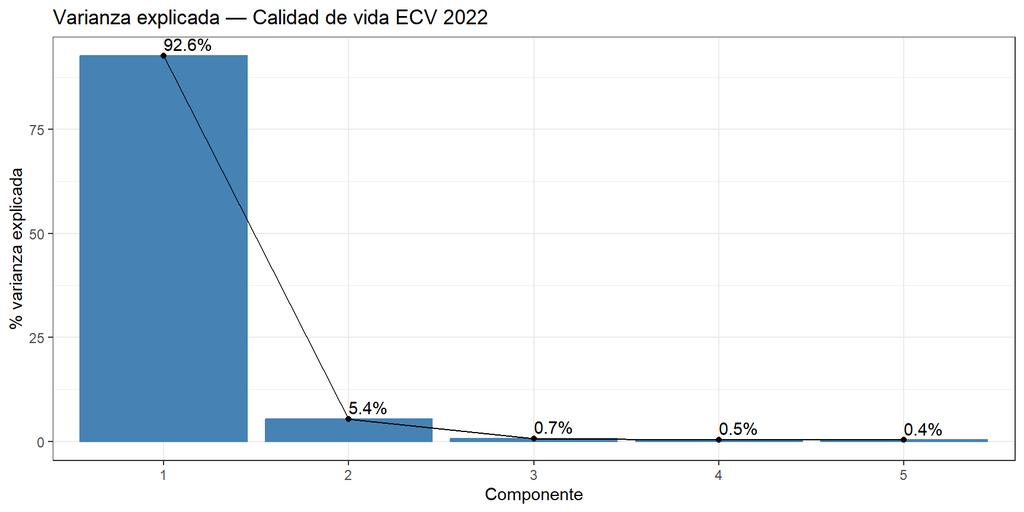

## Paso 2: HCPC — dendrograma

```r
res.clus.ecv <- HCPC(pca_ecv, graph = FALSE)
table(res.clus.ecv$data.clust$clust)
```

```
 1  2  3
 4 13 16
```

```r
fviz_dend(res.clus.ecv, cex = 0.6, palette = "jco",
          rect = TRUE, rect_fill = TRUE, horiz = TRUE,
          rect_border = "jco", labels_track_height = 0.8,
          main = "Dendrograma — Departamentos según calidad de vida")
```

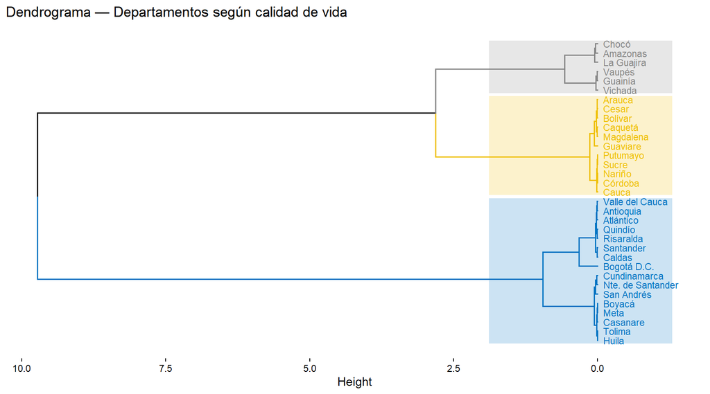

## Paso 3: Plano factorial por agrupación (clúster)

```r
fviz_cluster(res.clus.ecv, repel = TRUE,
             show.clust.cent = TRUE, palette = "jco",
             ggtheme = theme_minimal(),
             main = "Agrupación de departamentos (clúster) — Calidad de vida ECV 2022")
```

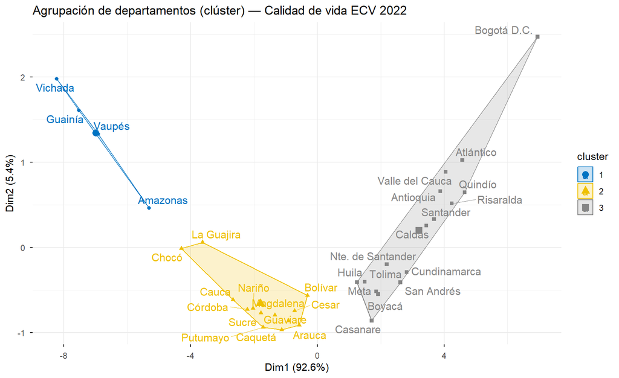

## Caracterización de las agrupaciones (clústeres)

`leen_adultos`: % de adultos que saben leer y escribir. `inv_ipm`: inverso del IPM (100 − IPM). `inv_hacinamiento`: inverso del % de hogares en hacinamiento (100 − % hacinamiento).

```r
desc_ecv <- map_dfr(names(res.clus.ecv$desc.var$quanti), function(k) {
  as.data.frame(res.clus.ecv$desc.var$quanti[[k]]) |>
    rownames_to_column("variable") |>
    mutate(cluster = k) |>
    select(cluster, variable, `Mean in category`, `Overall mean`, v.test) |>
    slice_max(order_by = abs(v.test), n = 4)
})
```

| Variable | Media en agrupación (clúster) | Media global | v.test |
| --- | --- | --- | --- |
| 1 |  |  |  |
| energia | 78.0 | 94.7 | -5.1 |
| leen_adultos | 81.2 | 92.1 | -4.5 |
| inv_ipm | 47.4 | 77.7 | -4.4 |
| afiliacion_salud | 74.4 | 86.7 | -4.4 |
| 2 |  |  |  |
| computador | 14.3 | 24.3 | -3.2 |
| internet | 20.9 | 33.6 | -3.1 |
| gas_natural | 8.9 | 22.2 | -3.0 |
| educ_superior | 8.6 | 13.1 | -3.0 |
| 3 |  |  |  |
| internet | 50.2 | 33.6 | 4.9 |
| computador | 37.1 | 24.3 | 4.9 |
| paredes_adec | 88.1 | 74.1 | 4.8 |
| piso_adec | 84.7 | 69.8 | 4.8 |

## Interpretación

- **Agrupación 1 (Clúster 1)** (4 dptos: Amazonas, Vaupés, Guainía, Vichada): valores **muy por debajo** de la media nacional en energía, alfabetización de adultos (`leen_adultos`), el indicador invertido de pobreza multidimensional (`inv_ipm`) y afiliación en salud. Es el grupo con las condiciones de vida más precarias — la Amazonía y la Orinoquía profundas.
- **Agrupación 2 (Clúster 2)** (13 dptos: Caribe, Pacífico, Arauca, Caquetá, Putumayo…): valores **por debajo** de la media en acceso a computador, internet, gas natural y educación superior — departamentos históricamente afectados por el conflicto y con menor cobertura de servicios.
- **Agrupación 3 (Clúster 3)** (16 dptos: Bogotá, Antioquia, Valle, eje cafetero, Santanderes…): valores **por encima** de la media en acceso a internet y computador, y en calidad de vivienda (paredes y piso adecuados) — la región Andina y las principales áreas metropolitanas.

## Objetos “parangón” de cada agrupación (clúster)

Son los departamentos **más representativos** (más cercanos al centro de su agrupación (clúster)):

```r
map_dfr(names(res.clus.ecv$desc.ind$para), function(k) {
  tibble(cluster = k, departamento = names(res.clus.ecv$desc.ind$para[[k]]),
         distancia = round(res.clus.ecv$desc.ind$para[[k]], 3))
}) |> gt(groupname_col = "cluster") |>
  tab_options(table.font.size = px(18), data_row.padding = px(3))
```

| departamento | distancia |
| --- | --- |
| 1 |  |
| Vaupés | 0.107 |
| Guainía | 0.606 |
| Vichada | 1.431 |
| Amazonas | 1.949 |
| 2 |  |
| Sucre | 0.190 |
| Nariño | 0.321 |
| Putumayo | 0.340 |
| Córdoba | 0.476 |
| Magdalena | 0.503 |
| 3 |  |
| Caldas | 0.297 |
| Cundinamarca | 0.636 |
| Santander | 0.637 |
| Antioquia | 0.881 |
| Risaralda | 1.117 |

# Estudio de caso 2: retomando el ACM — confianza institucional

## Contexto: Barómetro de las Américas

El **Barómetro de las Américas** (LAPOP) es la encuesta de opinión pública más grande de América Latina. La edición Colombia 2021 tiene 2 993 encuestados. Usa un diseño de **muestra dividida**: distintos módulos de preguntas van a diferentes subconjuntos.

El ejemplo usa seis preguntas del **mismo módulo** (n ≈ 1 368, escala 1–7):

| Variable | Dimensión |
| --- | --- |
| `b2` | Respeto por las instituciones políticas |
| `b3` | Derechos básicos bien protegidos |
| `b4` | Orgullo por el sistema político |
| `b6` | Apoyo al sistema político |
| `b32` | Confianza en el gobierno local |
| `b47a` | Confianza en las elecciones |

Las escalas 1–7 se recodifican: **Baja** (1–3) · **Media** (4) · **Alta** (5–7). El género (`q1tb`: Hombre/Mujer) se incluye como **variable suplementaria**.

## Recordando el ACM: LAPOP Colombia 2021

Retomamos el ejemplo de confianza institucional (b2, b3, b4, b6, b32, b47a; escalas recodificadas Baja/Media/Alta) con el género como variable suplementaria.

```r
lapop_raw <- read_dta(paste0(url, "COL_2021_LAPOP.dta"))

recode_trust <- function(x) {
  xn <- suppressWarnings(as.numeric(x))
  dplyr::case_when(
    xn %in% 1:3 ~ "Baja",
    xn == 4     ~ "Media",
    xn %in% 5:7 ~ "Alta",
    TRUE        ~ NA_character_
  )
}

lapop_acm <- lapop_raw |>
  transmute(
    Respeto = recode_trust(b2), Derechos = recode_trust(b3),
    Orgullo = recode_trust(b4), Apoyo = recode_trust(b6),
    GobLocal = recode_trust(b32), Elecciones = recode_trust(b47a),
    Genero = dplyr::case_when(as.numeric(q1tb) == 1 ~ "Hombre",
                               as.numeric(q1tb) == 2 ~ "Mujer",
                               TRUE ~ NA_character_)
  ) |> drop_na() |> mutate(across(everything(), factor))

acm_lapop <- MCA(lapop_acm,
                 quali.sup = which(names(lapop_acm) == "Genero"),
                 graph = FALSE)
```

## HCPC sobre las coordenadas del ACM

```r
res.clus.lapop <- HCPC(acm_lapop, graph = FALSE)
table(res.clus.lapop$data.clust$clust)
```

```
  1   2   3   4
487 126 368 385
```

```r
fviz_dend(res.clus.lapop, cex = 0.4, palette = "jco",
          rect = TRUE, rect_fill = TRUE,
          main = "Dendrograma — Confianza institucional LAPOP 2021")
```

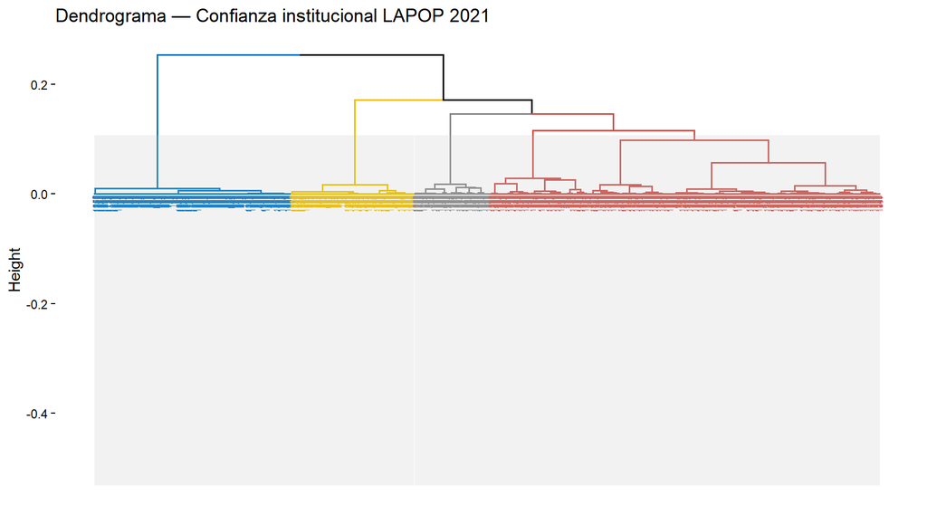

## Plano de objetos coloreado por agrupación (clúster)

```r
fviz_cluster(res.clus.lapop, geom = "point", alpha = 0.4,
             palette = "jco", ggtheme = theme_minimal(),
             main = "Encuestados LAPOP 2021 según legitimidad política")
```

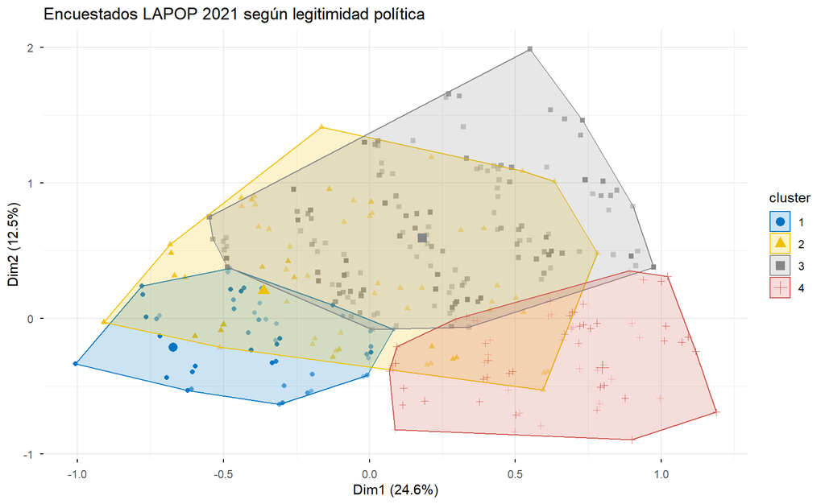

## Caracterización cualitativa de las agrupaciones (clústeres)

```r
desc_lapop <- map_dfr(names(res.clus.lapop$desc.var$category), function(k) {
  as.data.frame(res.clus.lapop$desc.var$category[[k]]) |>
    rownames_to_column("modalidad") |>
    mutate(cluster = k) |>
    select(cluster, modalidad, `Mod/Cla`, `Cla/Mod`, Global, v.test) |>
    slice_max(order_by = v.test, n = 4)
})
```

| Modalidad | % Mod/Cla | % Cla/Mod | % global | v.test |
| --- | --- | --- | --- | --- |
| 1 |  |  |  |  |
| Apoyo=Apoyo_Baja | 86.0 | 75.0 | 40.9 | 26.1 |
| Orgullo=Orgullo_Baja | 93.4 | 68.0 | 49.0 | 26.1 |
| Derechos=Derechos_Baja | 92.8 | 54.3 | 60.9 | 19.3 |
| Elecciones=Elecciones_Baja | 92.2 | 53.7 | 61.2 | 18.7 |
| 2 |  |  |  |  |
| Respeto=Respeto_Media | 100.0 | 95.5 | 9.7 | 28.0 |
| Derechos=Derechos_Baja | 77.8 | 11.8 | 60.9 | 4.2 |
| GobLocal=GobLocal_Baja | 67.5 | 12.0 | 51.8 | 3.7 |
| Elecciones=Elecciones_Baja | 75.4 | 11.4 | 61.2 | 3.5 |
| 3 |  |  |  |  |
| Orgullo=Orgullo_Media | 45.1 | 78.7 | 15.4 | 17.3 |
| Apoyo=Apoyo_Media | 44.8 | 75.7 | 16.0 | 16.7 |
| Derechos=Derechos_Media | 41.6 | 68.0 | 16.5 | 14.3 |
| Respeto=Respeto_Alta | 90.2 | 36.4 | 66.7 | 12.0 |
| 4 |  |  |  |  |
| Orgullo=Orgullo_Alta | 87.0 | 68.9 | 35.6 | 25.2 |
| Apoyo=Apoyo_Alta | 93.2 | 61.0 | 43.1 | 24.6 |
| Elecciones=Elecciones_Alta | 67.3 | 77.3 | 24.5 | 22.3 |
| Derechos=Derechos_Alta | 59.7 | 74.4 | 22.6 | 19.8 |

## De la teoría a la práctica

> El mismo flujo de trabajo: reducir dimensión, clasificar jerárquicamente y consolidar con K-medias; funciona igual sobre coordenadas de un **ACP** (variables cuantitativas) que de un **ACM** (variables cualitativas). Lo único que cambia es el objeto que se pasa a `HCPC()`.

# Laboratorio

## Datos del laboratorio

```r
library(pacman)
p_load(tidyverse, FactoMineR, factoextra, cluster, haven, janitor)

url <- "https://github.com/jgbabativam/EDM/raw/main/Datos/"
```

Cada grupo trabajará con una **semilla distinta**, un conjunto de variables cuantitativas para K-medias/jerárquico y un subconjunto de ítems cualitativos para el ACM + HCPC.

| Grupo | Semilla | Datos cuantitativos | ACM + HCPC: ítems p20 (Muestra_CC.csv) |
| --- | --- | --- | --- |
| 1 | 1357 | `SUEsolo2012.csv` (universidades públicas) | a, b, c, d, e |
| 2 | 2468 | `r14_Sci_Qs_Webometrics.csv` (universidades LatAm) | f, g, h, i, j |
| 3 | 3579 | `ecv_departamentos_2022.csv` (otro subconjunto de indicadores) | c, d, e, f, k |
| 4 | 9753 | `IPM2025.sav` (pobreza multidimensional) | a, g, h, i, j, k |
| 5 | 6813 | `ARWU_100_top.csv` (ranking mundial de universidades) | b, e, g, i, k |

## Laboratorio — K-medias (1/3)

Con el conjunto de datos cuantitativos asignado a su grupo:

1. Seleccione al menos **4 variables cuantitativas** relevantes y elimine observaciones con datos faltantes.
2. **Estandarice** las variables y justifique por qué es necesario en este caso.
3. Use `fviz_nbclust()` (WSS y silueta) para proponer un número de agrupaciones (clústeres) $k$.
4. Aplique `kmeans()` con el $k$ elegido y su semilla asignada (`set.seed()`).
5. Visualice la partición con `fviz_cluster()` y calcule la **silueta promedio** (`silhouette()`, `fviz_silhouette()`). ¿La calidad de la partición es adecuada?

## Laboratorio — Jerárquico (2/3)

6. Con la misma matriz estandarizada, construya la **matriz de distancias** (`dist()`) y aplique `hclust()` con al menos **dos criterios de enlace** distintos.
7. Grafique ambos dendrogramas. ¿Los cortes en el mismo número de grupos coinciden con la partición de K-medias?
8. Aplique un **ACP** sobre las mismas variables y luego `HCPC()` sobre el resultado. Compare el número de agrupaciones (clústeres) sugerido automáticamente con el que usted eligió en el punto 3.
9. Use `res.clus$desc.var$quanti` para **caracterizar** cada agrupación (clúster): ¿qué variables lo definen y en qué sentido (por encima o por debajo de la media)?
10. Nombre cada agrupación (clúster) con una etiqueta descriptiva y redacte un párrafo de interpretación.

## Laboratorio — ACM + HCPC (3/3)

Con los ítems de justificación para desobedecer la ley asignados a su grupo:

1. Aplique el **ACM** (`MCA()`) sobre los ítems asignados.
2. Aplique `HCPC()` sobre el resultado del ACM. ¿Cuántas agrupaciones (clústeres) sugiere automáticamente?
3. Grafique el dendrograma y el plano de objetos coloreado por agrupación (clúster).
4. Use `res.clus$desc.var$category` para identificar las modalidades que **tipifican** cada agrupación (clúster).
5. Agregue **ciudad** o **nivel educativo** (`Muestra_CC.csv`) como variable suplementaria en el ACM antes de correr `HCPC()`. ¿Alguna de estas variables se asocia significativamente con alguna agrupación (clúster)?
6. Elabore una **caracterización final**: nombre cada agrupación (clúster) según el perfil de justificaciones que lo tipifica.

# GRACIAS!

## Citación y derechos de autor

Este material fue elaborado por **Jimmy Corzo** y **Giovany Babativa-Márquez** y se distribuye bajo la licencia **Creative Commons Atribución-CompartirIgual 4.0 Internacional (CC BY-SA 4.0)**.

**Citación sugerida**

> Corzo, J., & Babativa-Márquez, J. G. (2026). *Materiales del curso Estadística Descriptiva Multivariada* (Versión 2026-1). Zenodo. https://doi.org/10.5281/zenodo.21730142

**Repositorio GitHub:** https://github.com/jgbabativam/EDM

**Sitio web del curso:** https://jgbabativam.github.io/EDM

**Licencia:** https://creativecommons.org/licenses/by-sa/4.0/

**Versión del material:** 2026-1 • **Última actualización:** Julio de 2026